# Titanic passenger data analysis

Alain Roghi - alain.roghi@airbus.com

This document is an a analysis of the Titanic passenger data. This analysis is based on data set titanic-data.csv downloaded from the Udacity P2 project page.

## Background information (extract from Wikipedia)

RMS Titanic was a British passenger liner that sank in the North Atlantic Ocean in the early morning of 15 April 1912, after colliding with an iceberg during her maiden voyage from Southampton to New York City. Of the 2,224 passengers and crew aboard, more than 1,500 died, making it one of the deadliest commercial peacetime maritime disasters in modern history. The largest ship afloat at the time it entered service, the RMS Titanic was the second of three Olympic class ocean liners operated by the White Star Line, and was built by the Harland and Wolff shipyard in Belfast. Thomas Andrews, her architect, died in the disaster.

## Problem statement

We want to be able to answer the following questions:

- What is percentage of surviving people for each passenger class
- Is there a correlation between surviving people of their respective passenger class
- What is the percentage of surviving people per gender
- What is the age distribution of surviving and died people
- What was the average fare per passenger class and associated standard deviation (paying passengers only)

```python
%matplotlib inline
%pylab inline

import numpy as np
import pandas as pd
import seaborn as sns
import matplotlib as mp

# Loading dataset
path = './'
passengers = pd.read_csv(path + 'titanic-data.csv')
passengers.head(3)
```

```
C:\Users\roghi\Documents\Data scientist\Anaconda\lib\site-packages\IPython\core\magics\pylab.py:161: UserWarning: pylab import has clobbered these variables: ['axes', 'title']
`%matplotlib` prevents importing * from pylab and numpy
  "\n`%matplotlib` prevents importing * from pylab and numpy"
```

|  | PassengerId | Survived | Pclass | Name | Sex | Age | SibSp | Parch | Ticket | Fare | Cabin | Embarked |
| --- | --- | --- | --- | --- | --- | --- | --- | --- | --- | --- | --- | --- |
| 0 | 1 | 0 | 3 | Braund, Mr. Owen Harris | male | 22.0 | 1 | 0 | A/5 21171 | 7.2500 | NaN | S |
| 1 | 2 | 1 | 1 | Cumings, Mrs. John Bradley (Florence Briggs Th... | female | 38.0 | 1 | 0 | PC 17599 | 71.2833 | C85 | C |
| 2 | 3 | 1 | 3 | Heikkinen, Miss. Laina | female | 26.0 | 0 | 0 | STON/O2. 3101282 | 7.9250 | NaN | S |

# Data format (source : Kaggle web site - https://www.kaggle.com/c/titanic/data)

VARIABLE DESCRIPTIONS: survival Survival (0 = No; 1 = Yes) pclass Passenger Class (1 = 1st; 2 = 2nd; 3 = 3rd) name Name sex Sex age Age sibsp Number of Siblings/Spouses Aboard parch Number of Parents/Children Aboard ticket Ticket Number fare Passenger Fare cabin Cabin embarked Port of Embarkation (C = Cherbourg; Q = Q ueenstown; S = Southampton)

SPECIAL NOTES: Pclass is a proxy for socio-economic status (SES) 1st ~ Upper; 2nd ~ Middle; 3rd ~ Lower

Age is in Years; Fractional if Age less than One (1) If the Age is Estimated, it is in the form xx.5

With respect to the family relation variables (i.e. sibsp and parch) some relations were ignored. The following are the definitions used for sibsp and parch.

Sibling: Brother, Sister, Stepbrother, or Stepsister of Passenger Aboard Titanic Spouse: Husband or Wife of Passenger Aboard Titanic (Mistresses and Fiances Ignored) Parent: Mother or Father of Passenger Aboard Titanic Child: Son, Daughter, Stepson, or Stepdaughter of Passenger Aboard Titanic

Other family relatives excluded from this study include cousins, nephews/nieces, aunts/uncles, and in-laws. Some children travelled only with a nanny, therefore parch=0 for them. As well, some travelled with very close friends or neighbors in a village, however, the definitions do not support such relations.

# Data exploration

We can already notice there are discrepencies between the file and the content description. Some headers are either not the same (Survived vs survival) or written with a different case (pclass vs Pclass).

We can also see that some information are not described (for instance the Fare for which we do not know the associated currency).

We will perform some basic data exploration on the whole file in order to check data quality.

```python
print "Number of values in each column"
print passengers.count()


print "\nCheck if their is non described values is some columns"
print "Survived %s" % passengers['Survived'].unique()
print "Pclass   %s" % passengers['Pclass'].unique()
print "Sex      %s" % passengers['Sex'].unique()
print "SibSp    %s" % passengers['SibSp'].unique()
print "Parch    %s" % passengers['Parch'].unique()
print "Embarked %s" % passengers['Embarked'].unique()
print "Fare data description"
passengers['Fare'].describe()
```

```
Number of values in each column
PassengerId    891
Survived       891
Pclass         891
Name           891
Sex            891
Age            714
SibSp          891
Parch          891
Ticket         891
Fare           891
Cabin          204
Embarked       889
dtype: int64

Check if their is non described values is some columns
Survived [0 1]
Pclass   [3 1 2]
Sex      ['male' 'female']
SibSp    [1 0 3 4 2 5 8]
Parch    [0 1 2 5 3 4 6]
Embarked ['S' 'C' 'Q' nan]
Fare data description
```

```
count    891.000000
mean      32.204208
std       49.693429
min        0.000000
25%        7.910400
50%       14.454200
75%       31.000000
max      512.329200
Name: Fare, dtype: float64
```

We see that there are some missing informations:

- Age data
- Cabin identification
- Embarquement harbour

As we are interested in people at the moment the boat sink, we will exclude people that did not embarqued from the whole study. It will be performed at next step. It impact only two rows from the dataset.

As we are not answering any question related to cabin, we won't do any modification nor filtering on the cabin information. We are missing cabin information for 687 over 891 (about 77%).

Age is missing on 177 rows over 891 (about 20%). In order to deal with these missing values, we could either:

- just not include the missing age records when performin an age related analysis
- estime the age of the passengers based using a linear regression model between fare and age using records having those values.

Within the data format description, it is already mentionned that some ages are already estimated ones. We consider not relevant to perform another age estimation based on passenger fare as we are missing the pricing policy of the White Star Line company. Therefore, missing age record will not be taken into account when performing age analysis. We will create a specific Age category column with an Unknown value when Age is not filled in.

We also notice that some passengers have 0 as ticket Fare. The format description do not mention any information about the Fare data. We can either imagine that some passengers get a free ride, or these people were crew memebers, or that 0 has to be considered as missing value. As mentionned earlier, we do not have any information about the White Star Line company pricing policy. Therefore, 0 Fare values records will not be taken into account when performing fare data analysis.

# Data modification

We will apply two modifications.

```python
def labelsurvive(s):
  return ('Survived' if s == 1 else 'Died')

def labelage(s):
  return ('Young' if s <= 12 else 'Teenager' if s <= 18 else 'Adult' if s <= 60 else 'Old' if s > 60 else 'Unknow' )

passengers['SurvivedT'] = passengers['Survived'].map(labelsurvive)
passengers['AgeCat'] = passengers['Age'].map(labelage)

# Remove non boarding passengers
passengers = passengers[(passengers['Embarked'] == 'Q') | (passengers['Embarked'] == 'S') | (passengers['Embarked'] == 'C')]

# Check modification
passengers.head(3)
```

|  | PassengerId | Survived | Pclass | Name | Sex | Age | SibSp | Parch | Ticket | Fare | Cabin | Embarked | SurvivedT | AgeCat |
| --- | --- | --- | --- | --- | --- | --- | --- | --- | --- | --- | --- | --- | --- | --- |
| 0 | 1 | 0 | 3 | Braund, Mr. Owen Harris | male | 22.0 | 1 | 0 | A/5 21171 | 7.2500 | NaN | S | Died | Adult |
| 1 | 2 | 1 | 1 | Cumings, Mrs. John Bradley (Florence Briggs Th... | female | 38.0 | 1 | 0 | PC 17599 | 71.2833 | C85 | C | Survived | Adult |
| 2 | 3 | 1 | 3 | Heikkinen, Miss. Laina | female | 26.0 | 0 | 0 | STON/O2. 3101282 | 7.9250 | NaN | S | Survived | Adult |

```python
print passengers.count()
print "Embarked %s" % passengers['Embarked'].unique()
print "AgeCat %s" % passengers['AgeCat'].unique()
```

```
PassengerId    889
Survived       889
Pclass         889
Name           889
Sex            889
Age            712
SibSp          889
Parch          889
Ticket         889
Fare           889
Cabin          202
Embarked       889
SurvivedT      889
AgeCat         889
dtype: int64
Embarked ['S' 'C' 'Q']
AgeCat ['Adult' 'Unknow' 'Young' 'Teenager' 'Old']
```

# Passenger class analysis

This section will show some passenger class analysis statistics.

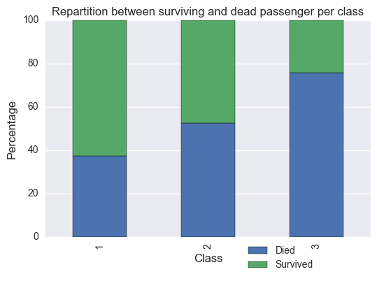

```python
%matplotlib inline

# this function normalise from aboslute values to percentage all figures from a data serie
def normalise(row):
    data = np.array(row)
    data[isnan(data)] = 0
    return 100 * row / data.sum()

# this function display a stacked bar chart with corresponding labels and titles
def plotstackedbar(data,label1,label2,leftanchor,xlabel,ylabel,title):
    chart = data.plot.bar(stacked = True)

    # modify legend
    handles, labels = chart.get_legend_handles_labels()
    labels[0] = label1
    labels[1] = label2
    chart.legend(handles, labels,bbox_to_anchor=(leftanchor, 0))

    # Set titles
    chart.set_xlabel(xlabel, fontsize=12)
    chart.set_ylabel(ylabel, fontsize=12)
    chart.set_title(title, fontsize=12)

survival_per_class = passengers.groupby(['Pclass','Survived'])['PassengerId']
data =  survival_per_class.count().unstack()
data = data.apply(normalise, axis='columns')

plotstackedbar(data,'Died','Survived',0.85,'Class','Percentage','Repartition between surviving and dead passenger per class')
```

```python
data = passengers.groupby(['Pclass'])['PassengerId'].count()
print "Number of passengers per class"
print data
print

print "Percentage of passenger per class"
print normalise(data)
print

data = passengers.groupby(['SurvivedT','Pclass'])['PassengerId']
data =  data.count().unstack()
print 'Passenger numbers'
print data
print

print "Dying and survived people ratio"
data = data.apply(normalise, axis='columns')
print data
print

print "Pearson correlation coef between the different variables"
print passengers.corr(method='pearson')
print
```

```
Number of passengers per class
Pclass
1    214
2    184
3    491
Name: PassengerId, dtype: int64

Percentage of passenger per class
Pclass
1    24.071991
2    20.697413
3    55.230596
Name: PassengerId, dtype: float64

Passenger numbers
Pclass       1   2    3
SurvivedT
Died        80  97  372
Survived   134  87  119

Dying and survived people ratio
Pclass             1          2          3
SurvivedT
Died       14.571949  17.668488  67.759563
Survived   39.411765  25.588235  35.000000

Pearson correlation coef between the different variables
             PassengerId  Survived    Pclass       Age     SibSp     Parch  \
PassengerId     1.000000 -0.005028 -0.035330  0.033681 -0.057686 -0.001657
Survived       -0.005028  1.000000 -0.335549 -0.082446 -0.034040  0.083151
Pclass         -0.035330 -0.335549  1.000000 -0.365902  0.081656  0.016824
Age             0.033681 -0.082446 -0.365902  1.000000 -0.307351 -0.187896
SibSp          -0.057686 -0.034040  0.081656 -0.307351  1.000000  0.414542
Parch          -0.001657  0.083151  0.016824 -0.187896  0.414542  1.000000
Fare            0.012703  0.255290 -0.548193  0.093143  0.160887  0.217532

                 Fare
PassengerId  0.012703
Survived     0.255290
Pclass      -0.548193
Age          0.093143
SibSp        0.160887
Parch        0.217532
Fare         1.000000
```

# Question 1 & Question 2 conclusion

We see that better the travel class was, better the survival rate was.

In absolute value, we see that more passengers form 1st class survived than 3rd class passengers even if 1st class passengers were 60% less numerous than 3rd class people. This result is coherent when looking to the correlation factor between class number and survival (-0.335549)

Within the survivor population, the 1st class passengers were well represented (around 40%) compared to the 2 others classes, but they were only around 24% of the total population.

In could be interesting to analyse the accident report in order to understand the reason why the 1st class people were over-represented within the survival population.

# Gender and age analysis

This section will show some passenger gender analysis statistics.

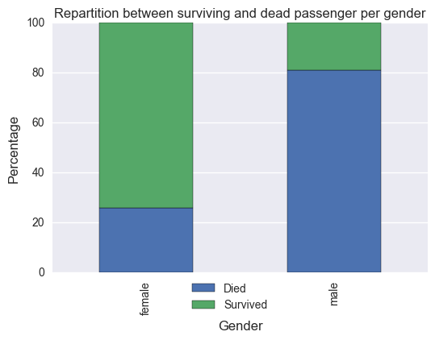

```python
survival_per_gender = passengers.groupby(['Sex','Survived'])['PassengerId']
data =  survival_per_gender.count().unstack()
data = data.apply(normalise, axis='columns')

title = 'Repartition between surviving and dead passenger per gender'
plotstackedbar(data,'Died','Survived',0.6,'Gender','Percentage',title)
plt.show()
```

```python
survival_per_cat = passengers.groupby(['AgeCat','SurvivedT'])['PassengerId']
data =  survival_per_cat.count().unstack()

print "Number dying and survival passengers per age category"
print data
print

print "Percentage dying and survival passengers per age category"
data = data.apply(normalise, axis='columns')
print data
print


survival_per_cat = passengers.groupby(['AgeCat','Sex','SurvivedT'])['PassengerId']
data =  survival_per_cat.count().unstack()

print "Number dying and survival passengers per age category and gender"
print data
print

print "Percentage dying and survival passengers per age category and gender"
data = data.apply(normalise, axis='columns')
print data
print
```

```
Number dying and survival passengers per age category
SurvivedT  Died  Survived
AgeCat
Adult       338       214
Old          17         4
Teenager     40        30
Unknow      125        52
Young        29        40

Percentage dying and survival passengers per age category
SurvivedT       Died   Survived
AgeCat
Adult      61.231884  38.768116
Old        80.952381  19.047619
Teenager   57.142857  42.857143
Unknow     70.621469  29.378531
Young      42.028986  57.971014

Number dying and survival passengers per age category and gender
SurvivedT         Died  Survived
AgeCat   Sex
Adult    female   42.0     147.0
         male    296.0      67.0
Old      female    NaN       2.0
         male     17.0       2.0
Teenager female    9.0      27.0
         male     31.0       3.0
Unknow   female   17.0      36.0
         male    108.0      16.0
Young    female   13.0      19.0
         male     16.0      21.0

Percentage dying and survival passengers per age category and gender
SurvivedT             Died    Survived
AgeCat   Sex
Adult    female  22.222222   77.777778
         male    81.542700   18.457300
Old      female        NaN  100.000000
         male    89.473684   10.526316
Teenager female  25.000000   75.000000
         male    91.176471    8.823529
Unknow   female  32.075472   67.924528
         male    87.096774   12.903226
Young    female  40.625000   59.375000
         male    43.243243   56.756757
```

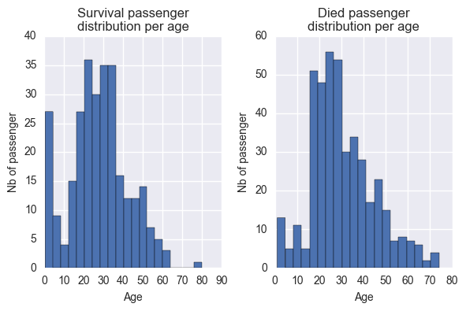

```
PassengerId    712
Survived       712
Pclass         712
Name           712
Sex            712
Age            712
SibSp          712
Parch          712
Ticket         712
Fare           712
Cabin          183
Embarked       712
SurvivedT      712
AgeCat         712
dtype: int64
```

```python
def createhist(ax, data, bins, xlabel, ylabel, title):
    ax.hist(data, bins, normed=0, histtype='bar')
    #ax.legend(prop={'size': 10})
    ax.set_xlabel(xlabel, fontsize=10)
    ax.set_ylabel(ylabel, fontsize=10)
    ax.set_title(title, fontsize=12)


fig, axes = plt.subplots(nrows=1, ncols=2)
ax0, ax1 = axes.flat

#We will restrict plotted data to valid ages only (it means > 0)
valid_age = passengers[(passengers['Age'] > 0)]
createhist(ax0, valid_age['Age'][(passengers['Survived'] == 1 )], 20, "Age","Nb of passenger","Survival passenger\ndistribution per age")
createhist(ax1, valid_age['Age'][(passengers['Survived'] == 0 )], 20, "Age","Nb of passenger","Died passenger\ndistribution per age")

plt.tight_layout()
plt.show()

print valid_age.count()
```

# Question 3 & 4 conclusion

We see that the percentage of surviving female is greater than percentage of surviving male. Nevertheless, we can see a different scheme according to age of passengers.

We see that young passengers survival rate was around 60% for male/female without gender distinction. This can also be obsrved on the two histograms. For the other age categories, we have a roughly similar survival rate for females (aroud 75%, expect for the 2 old ladies (100% survival rate)). But, for males, we have a much bigger dying rate for teenagers (from 12 to 18) and old people (> 60). It can be understandable for old people, but needs further investigation in order to be better understood this higher percentage for teenagers.

# Fare analysis

The Fare analysis will only focus on paying passengers, as we do not know what was the White Start Line pricing policy.

```python
# We exclude passenger that did not pay
data= passengers[(passengers['Fare'] > 0)]

print "Fare statistics"
print data['Fare'].describe()
print

print "Fare statistics per passenger class"
print data.groupby('Pclass')['Fare'].describe()
print

print "Fare statistics per passenger age category"
print data.groupby('AgeCat')['Fare'].describe()
print

print "Mean Fare per passenger age category and class"
print data.groupby(['AgeCat','Pclass'])['Fare'].mean()
print
```

```
Fare statistics
count    874.000000
mean      32.647539
std       49.942710
min        4.012500
25%        7.925000
50%       14.500000
75%       31.275000
max      512.329200
Name: Fare, dtype: float64

Fare statistics per passenger class
Pclass
1       count    209.000000
        mean      86.207715
        std       78.584940
        min        5.000000
        25%       32.320800
        50%       61.379200
        75%      106.425000
        max      512.329200
2       count    178.000000
        mean      21.358661
        std       13.083169
        min       10.500000
        25%       13.000000
        50%       15.022900
        75%       26.000000
        max       73.500000
3       count    487.000000
        mean      13.787875
        std       11.760718
        min        4.012500
        25%        7.750000
        50%        8.050000
        75%       15.500000
        max       69.550000
Name: Fare, dtype: float64

Fare statistics per passenger age category
```

[output cut: 46 more lines]

```
          2          20.854078
          3          11.340523
Old       1          58.428208
          2          10.500000
          3           7.820000
Teenager  1         122.537500
          2          21.172567
          3          13.414589
Unknow    1          64.877079
          2          17.452500
          3          14.840041
Young     1         126.239575
          2          28.740200
          3          24.634721
Name: Fare, dtype: float64
```

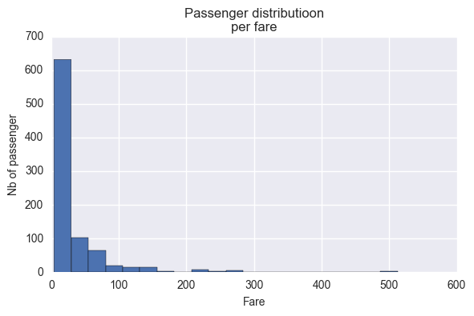

```python
fig, axes = plt.subplots(nrows=1, ncols=1)

createhist(axes, data['Fare'], 20, "Fare","Nb of passenger","Passenger distributioon\nper fare")

plt.tight_layout()
plt.show()
```

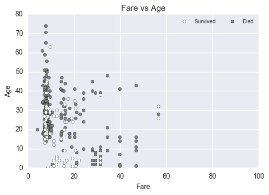

```python
def createscatter(ax, datax, datay, colors, xlabel, ylabel, title, xmin, xmax, ymin, ymax):
    chart = ax.scatter(datax, datay, c=colors, alpha = 1)
    ax.legend(prop={'size': 10})
    ax.set_xlabel(xlabel, fontsize=10)
    ax.set_ylabel(ylabel, fontsize=10)
    ax.set_title(title, fontsize=12)
    ax.set_xlim(xmin,  xmax)
    ax.set_ylim(ymin,  ymax)
    return chart

fig, axes = plt.subplots(nrows=1, ncols=1)

# we exlude from the data set passenger without a valid Age (AgeCat == Unknown)
datafare = data['Fare'][(data['AgeCat'] != 'Unknown')]
dataage = data['Age'][(data['AgeCat'] != 'Unknown')]
s2 = createscatter(axes,datafare[(data['Survived'] == 0) & (data['Pclass'] == 3)], dataage[(data['Survived'] == 0) & (data['Pclass'] == 3)], "gray","Fare","Age","Fare vs Age",0,100,0,80)
s1 = createscatter(axes,datafare[(data['Survived'] == 1) & (data['Pclass'] == 3)], dataage[(data['Survived'] == 1) & (data['Pclass'] == 3)], "white","Fare","Age","Fare vs Age",0,100,0,80)

plt.legend((s1,s2),('Survived', 'Died'),scatterpoints=1,loc='upper right',ncol=3,fontsize=8)

plt.show()
```

This chart focuses on class 3 passengers. It shows Age vs Fare and indicated if passenger survived or not.

We see that survival were mostly under 35 with low Fare.

# Question 5 conclusion

The average fare is 32 (currency?) but 50% of the passengers paid less than 14.5 (currency?).

We can also see that some limited people paid a huge fare (around 500) compared to other. We would need to investigate if this is a data quality issue or real information.

The mean fare for young and teenager is greater than the mean adult fare whatever the passenger class is. It could be interesting to understand what was the exact White Start Line fare policy.

We also saw that 3rd class survival were mostly under 35 with low Fare. It could be interesting to try to understand why we get this kind of output.

# Conclusion

We performed some statistics on Titanic passengers information. We can see some interesting information.

We saw that better the class was, better the survival rate is. We also saw that 1st class passenger were over-represented in the survival population. It could be interesting having a look at the accident report in order to understand why we get these results.

When looking to fares, we basically have coherent information, but we identified some data points (high fare) which need further invesgation to see if we do not have data quality issues.

It could be better to work on the full data set. It could also be usefull to add additional data within the data set. For instance, having information about the fact that the person was a crew member or a passenger could be usefull.

# Reference

In order to perform this project, I used to following information sources:

- Pandas official website: http://pandas.pydata.org/
- Matplotlib official website: http://matplotlib.org/
- Different forums but mainly stackoverflow : http://stackoverflow.com/